# Tarea 10

Martin Santamaria

24/8/2020

### Ley De Benford

Sea $X \sim Benford$ donde $D_X = \{1,2,3,4,5,6,7,8,9\}$

4. Defino aquí varias funciones que utilizaré luego

```r
# Función de probabilidad
dben = function(x){
  if(x >= 1 && x <= 9){
    sapply(x,function(x){log10(x + 1) - log10(x);});
  }else{
    0;
  }
}

# Función de distribución
pben = function(x){
  sapply(x,FUN=function(y){if(y < 1){return(0);}
    else if(y >= 9){
      return(1);
    }else{
      return(sum(dben(c(1:y))));}
    });
}

# Media
mben = function(){
  sum(sapply(c(1:9),function(x){x*(log10(x + 1) - log10(x));}));
}

# Varianza
vben = function(){
  s <- sum(sapply(c(1:9),function(x){x^2*(log10(x + 1) - log10(x));}));
  s - mben()^2
}
```

$$E(X)=\sum_{x\in X(\Omega)} x\cdot P_{X}(x)$$

```r
mben()
```

```
## [1] 3.440237
```

$$Var(X)=E(X^2)-(E(X))^2$$

```r
vben()
```

```
## [1] 6.056513
```

$$F_{X}(x_0)=\sum_{x\leq x_0} P_{X}(x)$$

Por ejemplo, calculamos $P(X \le 7)$

```r
pben(7)
```

```
## [1] 0.90309
```

```r
dben(c(1:9))
```

```
## [1] 0.30103000 0.17609126 0.12493874 0.09691001 0.07918125 0.06694679 0.05799195
## [8] 0.05115252 0.04575749
```

Claramente vemos que el dígito con mayor probabilidad (y muy posiblemente la moda en una muestra) es el 1.

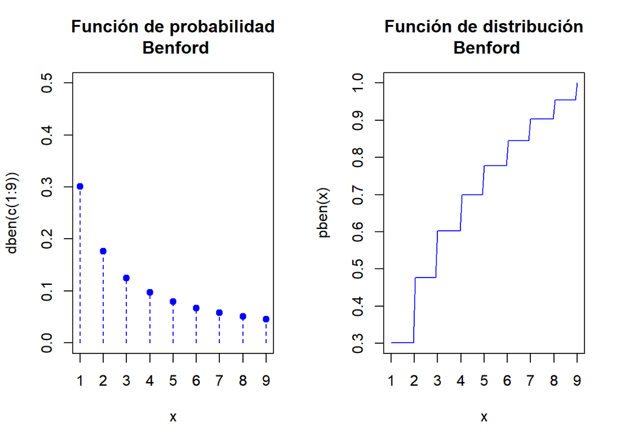

```r
par(mfrow=c(1,2))

plot(x=c(1:9),
     y=dben(c(1:9)),
     ylim=c(0,0.5),
     xlim=c(1,9),
     xlab="x",
     pch = 19,
     col = 'blue',
     main="Función de probabilidad\n Benford")
lines(x=c(1,2,3,4,5,6,7,8,9),
      y=c(dben(1),dben(2),dben(3),dben(4),dben(5),dben(6),dben(7),dben(8),dben(9)),
      type = "h",
      lty = 2,
      col="blue")
axis(1,seq(1,9,1))

curve(pben(x),
      xlim=c(1,9),
      col="blue",
      main="Función de distribución\n Benford")
axis(1,seq(1,9,1))
```

### Distribución de Pareto (Power law)

4. y e)

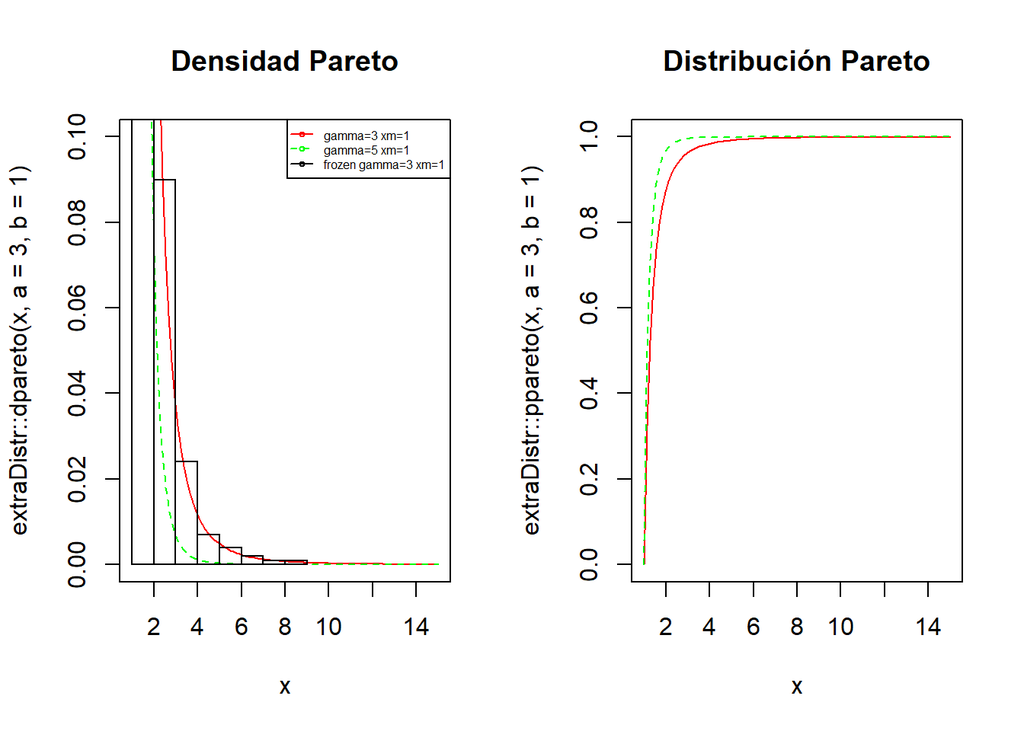

```r
par(mfrow=c(1,2)) # el parametro gamma es a y el parámetro xm es b

curve(extraDistr::dpareto(x,a=3,b=1),col="red",xlim=c(1,15),ylim=c(0,0.1),lty=1,main="Densidad Pareto")
curve(extraDistr::dpareto(x,a=5,b=1),add=TRUE,col="green",lty=2)
hist(extraDistr::rpareto(1000,3,1), add = TRUE, freq = FALSE,xlim=c(1,15))

legend("topright",pch=21,legend=c("gamma=3 xm=1","gamma=5 xm=1", "frozen gamma=3 xm=1"),col=c("red","green","black"), bty = "o", lty=c(1,2),cex=0.5)

curve(extraDistr::ppareto(x,a=3,b=1),col="red",xlim=c(1,15),ylim=c(0,1),lty=1,main="Distribución Pareto")
curve(extraDistr::ppareto(x,a=5,b=1),add=TRUE,col="green",lty=2)
```

6. En la distribución **power law** se suele denominar la distribución de escala libre debido a que es la unica distribución que es la misma independiente de la escala elegida. Supongamos que tenemos una distribución de probabilidad $p(x)$ para una cantidad $x$ que satisface $p(bx) = g(b)p(x)$ para cualquier valor $b$. O sea, si aumentamos la escala o unidades por el cual medimos $x$ por un factor de $b$, la forma de la distribución $p(x)$ no cambia.

### Distribución de Gumbel (teoría del valor extremo)

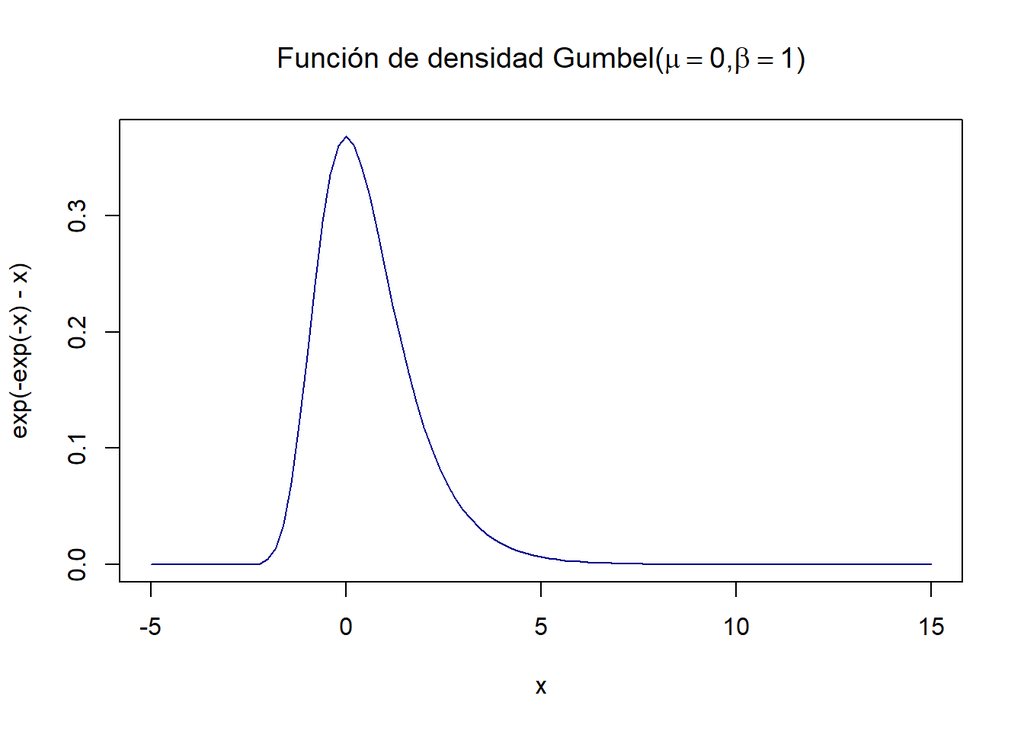

```r
library(latex2exp)

curve(exp(-exp(-x)-x),
      xlim = c(-5,15),
      col="darkblue",
      main=TeX("Función de densidad $Gumbel(\\mu = 0, \\beta = 1)$"))
```

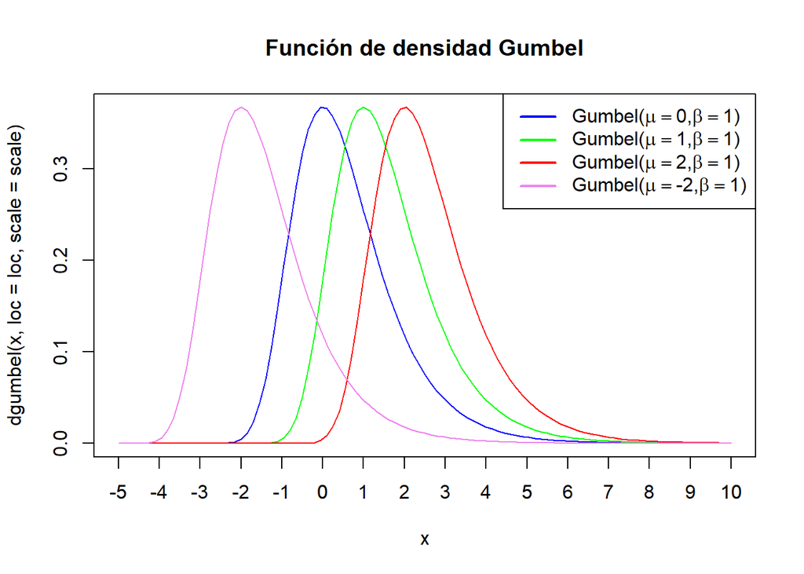

```r
library(evd)

loc = 0
scale = 1

curve(dgumbel(x,loc = loc, scale = scale),
      xlim = c(-5,10),
      col="blue",
      main="Función de densidad Gumbel")

curve(dgumbel(x,loc = loc + 1, scale = scale),
      col="green",
      add = TRUE)

curve(dgumbel(x,loc = loc + 2, scale = scale),
      col="red",
      add = TRUE)

curve(dgumbel(x,loc = loc - 2, scale = scale),
      col="violet",
      add = TRUE)

legend("topright",
       legend=c(TeX("$Gumbel(\\mu = 0, \\beta = 1)$"),
                TeX("$Gumbel(\\mu = 1, \\beta = 1)$"),
                TeX("$Gumbel(\\mu = 2, \\beta = 1)$"),
                TeX("$Gumbel(\\mu = -2, \\beta = 1)$")),
                col = c("blue","green","red","violet"),
                lty = c(1,1,1,1),
                lwd = c(2,2,2,2)
                )

axis(1,seq(-5,10,1))
```

Al cambiar $\mu$ lo que ocurre es que se desplaza la gráfica hacia la derecha (o izquierda) dependiendo del signo de $\mu$. Si $\mu > 0$ se desplaza hacia la derecha, y si $\mu < 0$ se deplaza hacia la izquierda.

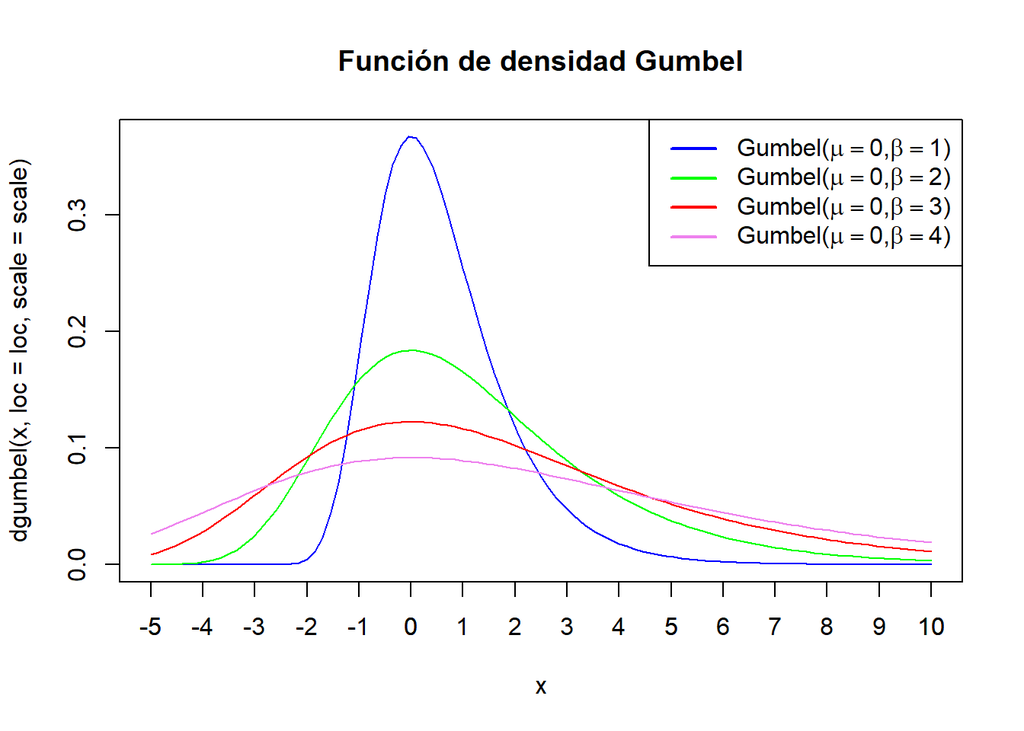

```r
library(evd)

loc = 0
scale = 1

curve(dgumbel(x,loc = loc, scale = scale),
      xlim = c(-5,10),
      col="blue",
      main="Función de densidad Gumbel")

curve(dgumbel(x,loc = loc, scale = scale + 1),
      col="green",
      add = TRUE)

curve(dgumbel(x,loc = loc, scale = scale + 2),
      col="red",
      add = TRUE)

curve(dgumbel(x,loc = loc, scale = scale + 3),
      col="violet",
      add = TRUE)

legend("topright",
       legend=c(TeX("$Gumbel(\\mu = 0, \\beta = 1)$"),
                TeX("$Gumbel(\\mu = 0, \\beta = 2)$"),
                TeX("$Gumbel(\\mu = 0, \\beta = 3)$"),
                TeX("$Gumbel(\\mu = 0, \\beta = 4)$")),
                col = c("blue","green","red","violet"),
                lty = c(1,1,1,1),
                lwd = c(2,2,2,2)
                )

axis(1,seq(-5,10,1))
```

Al variar $\beta$ se modifica el índice de curtosis. Esto es, los valores se encuentran más próximos o más alejados de la media con lo que la curva toma una forma con más punta o bien más aplanada. Con valores bajos de $\beta$ cercanos a cero, la curva es más puntiaguda mientras que para valores altos tiene forma más llana.

Sea $X$ una v.a. con distribución $Gumbel(\mu, \beta)$

$$E(X) = \mu \ + \ \beta \gamma$$

donde $\gamma$ es la constante de Euler cuyo valor es 0.5772157.

Asi nos quedaría

$$E(X) = \mu \ + \ (0.5772157)\beta$$

La varianza es

$$Var(X) = \frac{\pi^2}{6}\beta^2$$

```r
# Esperanza
mgumbel = function(loc,scale){
  loc + (-digamma(1)*scale);
}

# Varianza
vgumbel = function(scale){
  ((pi^2)/(6))*scale^2;
}
```

#### En `Python`

3. y d)

```python
from scipy.stats import gumbel_r
import numpy as np
import matplotlib.pyplot as plt

loc = 0
scale = 1

fig, ax = plt.subplots(1,1)
x = np.linspace(-5,10,100)

ax.plot(x, gumbel_r.pdf(x,loc,scale), 'b-', lw = 1, alpha = 0.7, label = "Gumbel(0,1)")
ax.plot(x, gumbel_r.pdf(x,loc + 1,scale), 'g-', lw = 1, alpha = 0.7, label = "Gumbel(1,1)")
ax.plot(x, gumbel_r.pdf(x,loc + 2,scale), 'r-', lw = 1, alpha = 0.7, label = "Gumbel(2,1)")
ax.plot(x, gumbel_r.pdf(x,loc - 2,scale), color='violet', ls = '-', lw = 1, alpha = 0.7, label = "Gumbel(-2,1)")

ax.legend(loc = "best", frameon= False)

plt.xticks(np.arange(-5,11,1))
```

[output not shown]

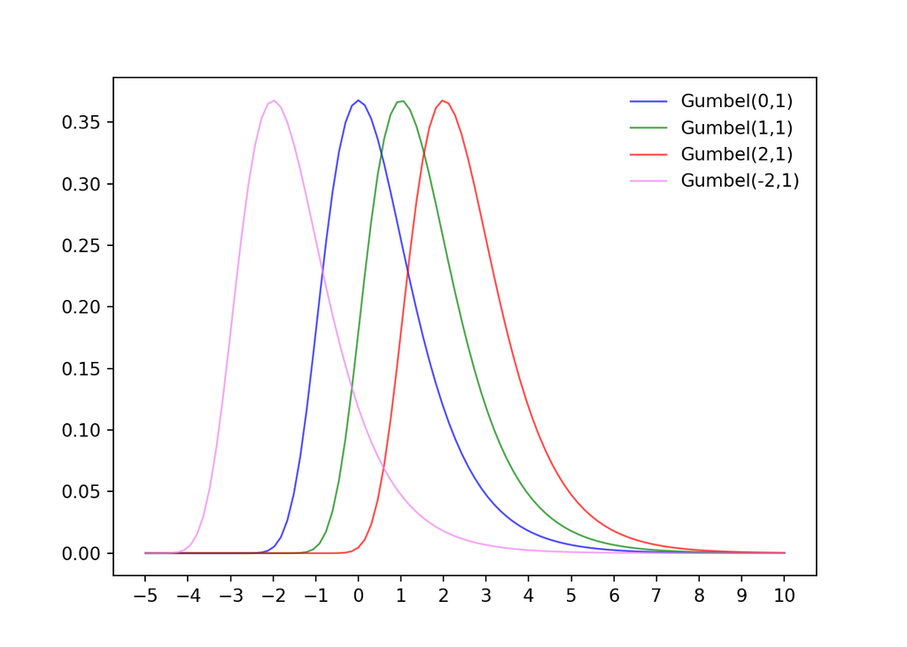

```python
plt.show()
```

```python
fig, ax = plt.subplots(1,1)
x = np.linspace(-5,10,100)

ax.plot(x, gumbel_r.pdf(x,loc,scale), 'b-', lw = 1, alpha = 0.7, label = "Gumbel(0,1)")
ax.plot(x, gumbel_r.pdf(x,loc,scale + 1), 'g-', lw = 1, alpha = 0.7, label = "Gumbel(0,2)")
ax.plot(x, gumbel_r.pdf(x,loc,scale + 2), 'r-', lw = 1, alpha = 0.7, label = "Gumbel(0,3)")
ax.plot(x, gumbel_r.pdf(x,loc,scale + 3), color='violet', ls = '-', lw = 1, alpha = 0.7, label = "Gumbel(0,4)")

ax.legend(loc = "best", frameon= False)

plt.xticks(np.arange(-5,11,1))
```

[output not shown]

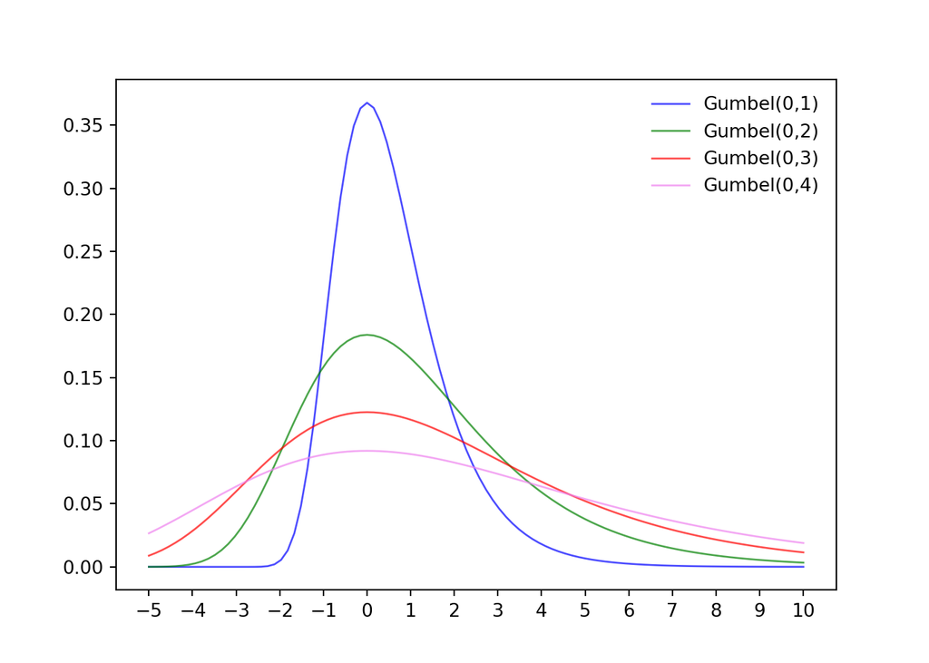

```python
plt.show()
```

Verifiquemos las fórmulas de la esperanza y la varianza del apartado e)

$$X \sim Gumbel(0,1)$$

```python
m,v = gumbel_r.stats(loc = 0, scale = 1, moments = 'mv')

print(f"E(X) = {m}")
```

```
## E(X) = 0.5772156649015329
```

```python
print(f"VAR(X) = {v}")
```

```
## VAR(X) = 1.6449340668482264
```

Con las fórmulas

```r
m = mgumbel(0,1)
v = vgumbel(1)
```

$E(X) =$ 0.5772157

$Var(X) =$ 1.6449341

$$Y \sim Gumbel(2,3)$$

```python
m,v = gumbel_r.stats(loc = 2, scale = 3, moments = 'mv')

print(f"E(Y) = {m}")
```

```
## E(Y) = 3.7316469947045987
```

```python
print(f"VAR(Y) = {v}")
```

```
## VAR(Y) = 14.804406601634037
```

Con las fórmulas

```r
m = mgumbel(2,3)
v = vgumbel(3)
```

$E(Y) =$ 3.731647

$Var(Y) =$ 14.8044066

$$Z \sim Gumbel(-2,4)$$

```python
m,v = gumbel_r.stats(loc = -2, scale = 4, moments = 'mv')

print(f"E(Z) = {m}")
```

```
## E(Z) = 0.30886265960613146
```

```python
print(f"VAR(Z) = {v}")
```

```
## VAR(Z) = 26.318945069571622
```

Con las fórmulas

```r
m = mgumbel(-2,4)
v = vgumbel(4)
```

$E(Z) =$ 0.3088627

$Var(Z) =$ 26.3189451